# Why Git, GitHub and R Are Good Friends

Roopam Das/401060784/das.roopam@stud.hs-fresenius.de

# Introduction

This presentation explains why Git, GitHub and R work effectively when combined in software development and analytical workflows. These tools integrate into a structured, collaborative, and reproducible system. Git is a version manager, GitHub supports collaboration and accessibility, and R is a powerful statistical and data-analysis environment. Together, they support documentation, clarity in decision-making, and efficient project flow.

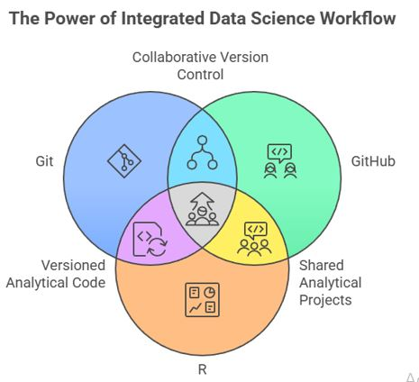

# Understanding Git

Git is a distributed version control system that tracks changes, protects analytical work, and allows experimentation safely.

## Key Functions

- Maintains historical snapshots
- Supports branching for experimentation
- Prevents conflicts in collaborative work
- Enables restoration of previous versions
- Provides a transparent audit trail

[figure not shown]

# Understanding GitHub

GitHub is a cloud-based platform built on Git, providing collaboration, automation, and version-controlled project management.

## Collaboration Features

- Pull requests
- Issue tracking
- Project boards
- Automated testing
- Cloud repository hosting

[figure not shown]

# Understanding R

R is an open-source analytic environment for statistical modelling, visualization, and reproducible research.

## Key Features

- Thousands of packages for modelling and automation
- High-quality visualizations
- Tidyverse, RMarkdown, and Quarto support workflow organization
- Strong emphasis on transparency and reproducibility

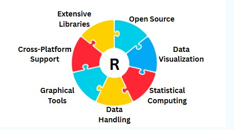

# Why These Tools Complement Each Other

Git, GitHub, and R each serve unique purposes but integrate seamlessly for effective workflows.

## Why They Work Together

- Git organizes analytical code
- GitHub manages collaboration
- R performs modelling and visualization
- Integration reduces errors
- Ensures reproducible workflows

[figure not shown]

# Enhancing Reproducible Research

Version control workflows strengthen transparency and long-term collaboration

## Reproducibility is essential in modern analytics

- Git records every analytical decision
- GitHub shares decisions with teams
- R executes computation transparently
- R Markdown and Quarto ensure synchronized documentation

[figure not shown]

# Supporting Collaboration and Teamwork

Git and GitHub provide structure and accountability.

## Team Advantages

- Parallel development via branching
- Peer-review via pull requests
- Issue tracking improves communication
- Encourages coordinated development
- Maintains project consistency

[figure not shown]

# Improving Project Organization

Git and GitHub ensuring clear version tracking, seamless collaboration, and a well-organized analytical environment.

## Git and GitHub strengthen project structure for R workflows.

- Versioning preserves scripts, figures, and data
- GitHub offers planning, reviews, and discussions
- Encourages frequent, meaningful commits
- Supports scalable and complex projects

[figure not shown]

# Real-World Applications

Git, GitHub, and R support data-driven processes in many sectors.

## Common Use Cases

- Reproducible research
- Forecasting and dashboards
- Government data transparency
- Open-source R package development
- Education in analytics

[figure not shown]

# Conclusion

Git, GitHub, and R form a complementary ecosystem for analytical work. Together, they create a reproducible, transparent, and collaborative environment that strengthens data science practice across industries.

[figure not shown]